# Assignment 3: Sentiment Classification Reflection

## 1. Training Dynamics

*Focus on your MLP and LSTM implementations*

- Did your models show signs of **overfitting** or **underfitting**? What architectural or training changes could address this?
- How did using **class weights** affect training stability and final performance?
1. From the plot, the behavior of MLP model training is quite stable. The training F1 and val F1 don’t have too many difference. The loss of val decreases gradually and doesn’t increase. So there is no underfitting or overfitting. Comparing MLP, the macro F1 score is higher than MLP’s, but there is obvious difference between training line and validation line. The training macro F1 score is higher than 0.9, while the validation macro F1 score is stable at 0.75. Moreover, validation loss begins increasing after around epoch 15. Thus, it shows obvious overfitting.
2. Class weight can balance the gap between different classes and improve the macro F1. It can penalize the errors in minority classes more heavily, which the model can learn better decison boundaries. In this question,since the dataset is imbalanced and the neutral class dominates most samples, without class weight the model may mainly predict neutral to get high accuracy. However, this will reduce the performance on negative and positive classes.

### MLP Training Curves

#### Loss Curve

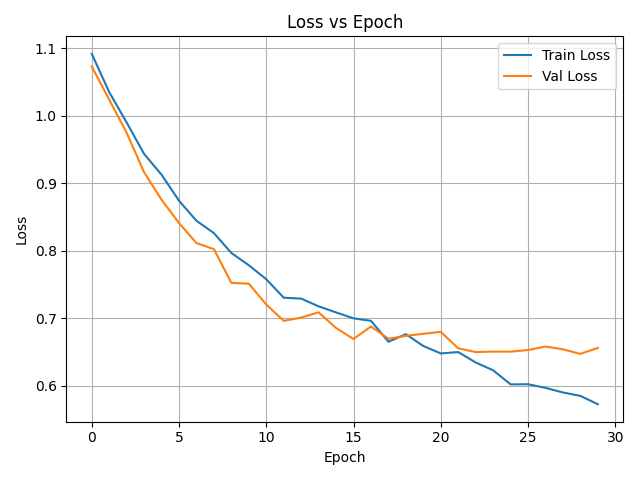

MLP Loss

#### Macro F1 Curve

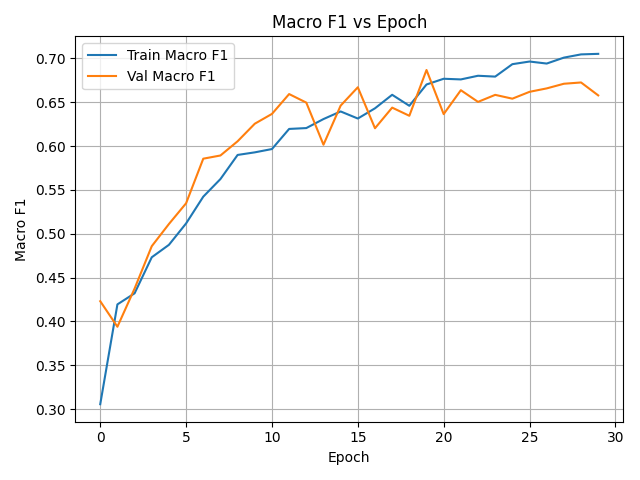

MLP F1

### LSTM Training Curves

#### Loss Curve

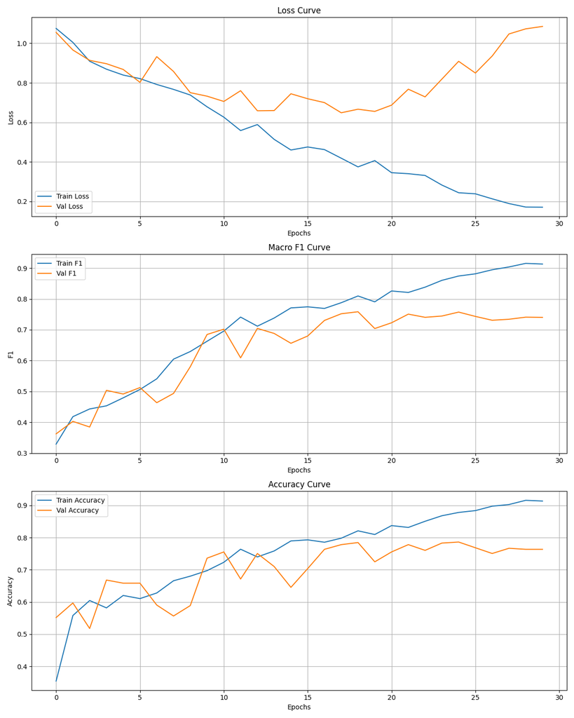

LSTM Loss

#### Macro F1 Curve

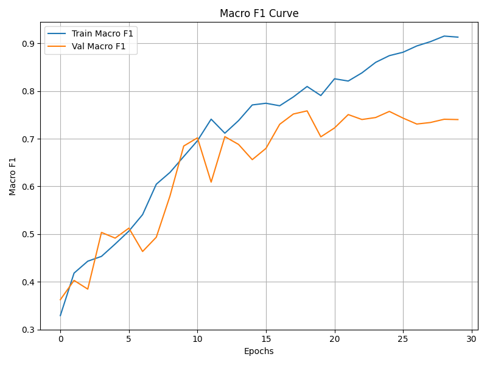

LSTM F1

## 2. Model Performance and Error Analysis

*Focus on your MLP and LSTM implementations*

- Which of your two models **generalized better** to the test set? Provide evidence from your metrics.
- Which **sentiment class** was most frequently misclassified? Propose reasons for this pattern.
1. LSTM shows better performance on generalization. Since the test macro F1 score of LSTM is 0.728, which is higher than MLP’s 0.693. Also, the test accuracy of LSTM is 0.748, which is higher than MLP 0.728. Compared with MLP, LSTM improves the Negative class performance significantly， F1 increases from 0.66 to 0.722. This indicates that LSTM can better capture contextual information and word order.
2. Positive is the easiest class to be misclassifed. Although it seems like the number of misclassification of neutral is the most, it has the largest number of samples.For example, in the MLP model, 53 positive samples are predicted as neutral. In the LSTM model, 44 positive samples are predicted as neutral. This shows that the model tends to predict Neutral when the sentiment signal is not strong. Besides that, Positive has the lowest F1 score compared to the other classes. For reasons: the dataset is imbalanced firstly. Secondly, financial informtion doesn’t tend to positive expression or mixes some confusing expression. Besides that no matter the MLP or LSTM have limitations of capture context.

### MLP Confusion Matrix

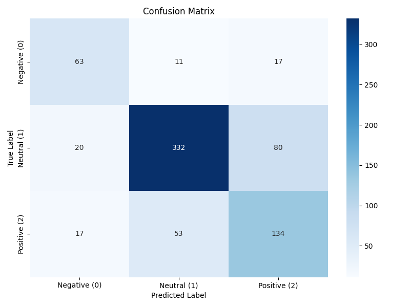

MLP Confusion Matrix

### LSTM Confusion Matrix

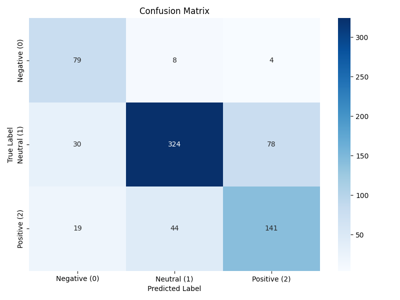

LSTM Confusion Matrix

## 3. Cross-Model Comparison

*Compare all six models: MLP, RNN, LSTM, GRU, BERT, GPT*

- How did **mean-pooled FastText embeddings** limit the MLP compared to sequence-based models?
- What advantage did the LSTM’s **sequential processing** provide over the MLP?
- Did **fine-tuned LLMs** (BERT/GPT) outperform classical baselines? Explain the performance gap in terms of pretraining and contextual representations.
- **Rank all six models** by test performance. What architectural or representational factors explain the ranking?
1. Since the mean-pooled FastText embeddings is static which ignores contextual information and sequence structure. It averages the vector into a single vector, which loses the information sequently. It treat each word independently. For example, it may classify the “not bad” as “bad”, a positive word into a negative word mistakenly.
2. LSTM can capture the sequence of sentence and the dependence of word by word, which keeps the contextual information in the hidden layers. For example, it can capture “not bad” as a negative expression successfully.
3. Yes, fine-tuned LLMs outperform classical baselines. For pretraining，BERT and GPT are pretrained on large corpora before fine-tuning. During pretraining, they learn rich semantic knowledge, syntactic patterns, and contextual relationships between words. So they have strong language understanding. For contextual representations: instead of static FastText embeddings, LLMs can generate contextualized embeddings. It can capture a word meaning based on surrounding context. For example, it can capture “not bad” as a negative expression successfully. Thus, LLMs can capture sentiment information in details, long sentence and sentence structure.
4. From test macro F1 scores, RNN (0.6618) < MLP (0.6926) < LSTM (0.7280) < GRU (0.7472) < BERT (0.7968) < GPT (0.8083)
- RNN performs the worst. Although it follows sentences sequentially, it has problem with vanishing gradient and has limited ability to capture long sentences.
- MLP performs better than RNN but still worse. Since it uses static mean-pooled FastText embeddings and ignores word order, it cannot capture contextual relationships between words.
- LSTM improves a lot. It has gate mechanism, which can control information flow and capture longer contextual dependencies. This helps improve imbalance of minority class performance and macro F1.
- GRU performs slightly better which also has gating mechanisms but has a simpler structure, which make optimization more stable. It develop higher macro F1 and improve better balance across classes.
- BERT and GPT significantly outperform all classical baselines. Since the large-scale pretraining and contextualized embeddings. LLMs are pretrained on huge corpora and learn lots of semantic and contextual representations before fine-tuning. They can generate contextualized embeddings, meaning the representation of a word depends on its surrounding context.
- Between BERT and GPT, GPT has slightly higher macro F1 in this experiment. Both models capture long-range dependencies and complex sentence structures effectively, which explains the large performance gap compared to classical models. Overall, the results show that the more the model understands context, the better it performs. Models with pretraining and contextual embeddings clearly have an advantage over classical neural networks.

## AI Use Disclosure (Required)

If you used any AI-enabled tools (e.g., ChatGPT, GitHub Copilot, Claude, or other LLM assistants) while working on this assignment, you must disclose that use here. The goal is transparency-not punishment.

In your disclosure, briefly include: - **Tool(s) used:** (name + version if known) - **How you used them:** (e.g., concept explanation, debugging, drafting code, rewriting text) - **What you verified yourself:** (e.g., reran the notebook, checked outputs/plots, checked shapes, read documentation) - **What you did *not* use AI for (if applicable):** (optional)

You are responsible for the correctness of your submission, even if AI suggested code or explanations.

I used chat gpt for clarifying ans learning the code of RNN.py, since I want to identify the logistic of it. Then I ask chat gpt what key difference between them. Also using chat gpt for debugging. I just verified myself by passing the requirement of macro F1 score.